# Memory, Lode, and LeanContext

What pi-skills has today, what the alternatives are, and what integrating them would mean

2026-08-16

## 0. Summary

Six systems are on the table. Five are external; one is ours.

| System | Substrate | Written by | History | Verdict for us |
| --- | --- | --- | --- | --- |
| **pi-skills `memory`** | SQLite/WAL via DuckDB, append-only statements | agent | per-field, full `as_of` | **the authority — extend it** |
| **Lode Coding** | `lode/` markdown tree | agent, on request | git only, per file | take the *vocabulary*, reject the files |
| **LeanContext** | `CONSTITUTION.md` + `MANIFEST.md` + `.context/` | human | none (manual `Status:` line) | take the *tier semantics* and the admission test |
| **Claude Code CLAUDE.md / rules** | markdown hierarchy | human | git only | take `paths:` glob triggering |
| **Claude Code auto memory** | `~/.claude/projects/<repo>/memory/` | Claude | `modified` timestamp | take the enforced index budget |
| **Anthropic CMA memory stores** | server-side documents | either | immutable per-document versions + **redact** | take **redaction** |

Decisions already settled in discussion:

- No `lode/` directory, no markdown sprawl, no VFS.
- Lode becomes a **vocabulary and a graph scope inside `memory`**, not a second store.
- Project knowledge reaches git as a **generated single-file export**, never as the authority.

## 1. What we have today: the `memory` extension

### 1.1 Physical core

Three tables. Everything else is a view.

```
memo.transactions (transaction_id, transaction_time, operation, session_id, receipt)
memo.statements   (transaction_id, ordinal, stanza, subject, predicate,
                   object, value, datatype, language, graph)
memo.memory_meta  (schema_version = "1")   memo.memory_counter (transaction)
```

`extensions/memory/schema.sql` · `extensions/memory/store.ts`

### 1.2 The one semantic idea: slots supersede, they do not overwrite

A **slot** is `(graph, subject, predicate)`. Appending a statement to an occupied slot supersedes the old value without rewriting it, so every field carries its own validity interval and the whole store can be replayed at any transaction.

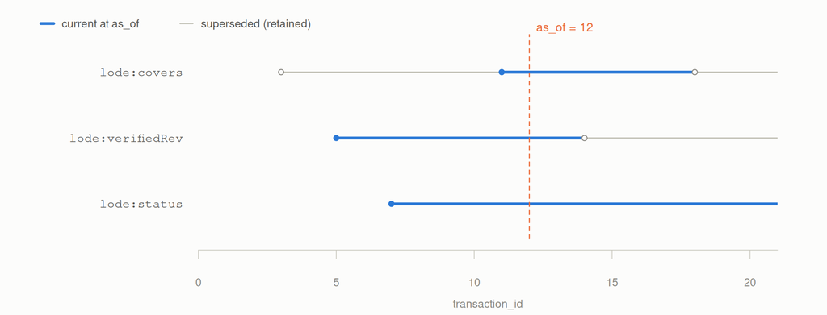

One `UPDATE` of a single temp row retargets every `as_of_*` view at once:

| View | What it gives | Where |
| --- | --- | --- |
| `statement_history` | `valid_from` / `valid_to` per slot, via `lead()` | `schema.sql:71` |
| `current_statement` | the head of every slot | `schema.sql:87` |
| `as_of_statement` | the head **as of** a chosen transaction | `session.sql:9` |
| `memory_query_context` | one temp row (`as_of_transaction`, `line_budget`) | `session.sql:3` |

`session.sql` runs on both the write connection (`store.ts:129`) and the isolated read-only `sql` connection (`store.ts:313`), so `memory sql` sees the same views.

### 1.3 Notes, summaries, and the wake frontier

| Layer | Mechanism | Bound |
| --- | --- | --- |
| Note | stanza `memory:note/<tx>`, one line | **280 UTF-8 bytes** |
| Summary tree | every aligned power-of-two block of the note stream, compressed by `nap` | source-hash checked |
| Wake frontier | recursive binary walk biased toward the present | `line_budget` rows |
| Recall | process-local DuckDB FTS over `note_statement`, bm25 | rebuilt per watermark |
| `sql` | read-only connection, no filesystem or network, bounded rows/memory/threads/runtime | hard |

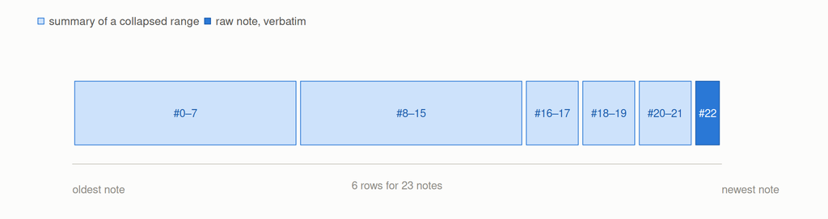

### 1.4 Where context actually enters the model

Memory policy is stable system text; task-conditioned memory arrives in a transient projection. Plannotator phase messages live in conversation history. Tree navigation, compaction, and result eviction can change the active prefix; cache reuse depends on the host and provider.

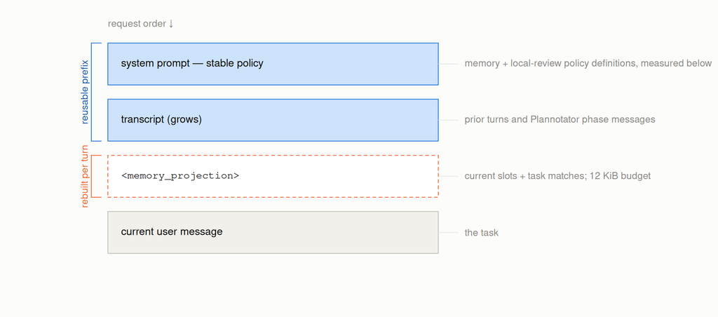

`buildTurnProjection()` in `extensions/memory/index.ts` combines current global and project slots with task-matched current records, deduplicates them, and applies a 12 KiB byte budget including rendered metadata. Wake history is retrieved explicitly. The transient projection is keyed by session, working directory, project override, user timestamp, and prompt hash. It is reused through the tool loop, never persisted, and replaced rather than accumulated. A write therefore changes retrieval on the **next** user turn. Around it, `context-budget` caps each built-in inspection result at 12 KiB and the aggregate at 64 KiB. Evicting an older result to retain fresh evidence can change the active context; bounded output is not a cache-hit guarantee.

### 1.5 Limits worth remembering

| Field | Cap |
| --- | --- |
| note text | 280 bytes, one line |
| stanza / subject | 300 bytes |
| predicate / graph | 200 bytes |
| object | 500 bytes |
| statement `value` | one line (no byte cap enforced) |
| `memory:system` graph | reserved for derived summaries |
| `SCHEMA_VERSION` | `"1"`, strict equality — a bump breaks existing DBs |

Adding **new views with new names** needs no version bump. Lode needs no new tables.

## 2. What Claude Code actually runs (this session, right now)

Four separate systems ship under the name “memory”. They are not variants of each other.

### 2.1 CLAUDE.md hierarchy — human instructions

| Scope | Location | Shared with |
| --- | --- | --- |
| Managed policy | `/etc/claude-code/CLAUDE.md` (Linux) | everyone on the machine, cannot be excluded |
| User | `~/.claude/CLAUDE.md` | you, all projects |
| Project | `./CLAUDE.md` or `./.claude/CLAUDE.md` | the team, via git |
| Local | `./CLAUDE.local.md` | you, this project (gitignored) |

- Files are **concatenated**, root-of-tree downward, so the most specific is read last. Subdirectory files load lazily when Claude reads a file there.
- `@path/to/file` imports, relative to the importing file, **max 4 hops**; backticked paths are not imported. Imports do not save context — they still load at launch.
- `.claude/rules/*.md` with `paths:` glob frontmatter load **only when Claude reads a matching file**. This is the one genuinely lazy tier.
- Target **under 200 lines**. `claudeMdExcludes` skips other teams’ files in a monorepo.
- Delivered **as a user message after the system prompt**, explicitly not as system prompt. Not enforcement: *“to block an action regardless of what Claude decides, use a PreToolUse hook.”*

### 2.2 Auto memory — the system I am running under

Storage for this very session: `/root/.claude/projects/-root-pi-skills/memory/` — currently **empty**; nothing has been saved for this repo yet.

| Property | Value |
| --- | --- |
| Scope | derived from the **git repository** — all worktrees and subdirectories share one directory |
| Sync | machine-local; never shared across machines or cloud |
| Loaded each session | `MEMORY.md` only, **first 200 lines or 25 KB**, whichever comes first |
| Topic files | read on demand with ordinary file tools |
| Retention | excluded from the transcript cleanup sweep |
| Subagents | separate directory; a fork inherits the parent’s |
| Over budget | the write succeeds, then the harness **returns an error telling Claude to rewrite the index** |
| Freshness | a `modified` ISO-8601 timestamp is stamped into frontmatter on write |

The instructions I carry in my system prompt right now, verbatim in shape:

```markdown
---
name: <short-kebab-case-slug>
description: <one-line summary, used to decide relevance during recall>
metadata:
  type: user | feedback | project | reference
---

<the fact; for feedback/project, follow with **Why:** and **How to apply:** lines.
 Link related memories with [[their-name]].>
```

with these rules attached:

- **One file, one fact.** Types: `user` (who you are), `feedback` (how I should work, with the why), `project` (ongoing work not derivable from code or git), `reference` (URLs, dashboards, tickets).
- Link liberally with `[[name]]`; a link to a memory that does not exist yet is a marker, not an error.
- After writing, add **one line** to `MEMORY.md`: `- [Title](file.md) — hook`. The index is loaded every session; never put content there.
- Check for an existing file covering the fact and update it rather than duplicating. Delete memories that turn out wrong.
- **Do not save what the repo already records** — code structure, past fixes, git history, CLAUDE.md. If asked to save one of those, ask what was non-obvious and save that instead.
- Recalled memories arrive inside `<system-reminder>` blocks: background context, not instructions, and true only as of when they were written. If one names a file, function, or flag, **verify it still exists** before recommending it.
- Convert relative dates to absolute.

Read that list against ours and the overlap is striking: a knowledge-boundary rule, one-fact-per-record, a bounded always-loaded index, a staleness warning, and a dedupe-before-write rule — the same five things LeanContext specifies in prose and we want to specify in SQL.

### 2.3 The API memory tool (`memory_20250818`)

Client-side. Claude issues `view` / `create` / `str_replace` / `insert` / `delete` / `rename` against a `/memories` directory; **you implement the backend**. Pairs with context editing (`clear_tool_uses_20250919`) and server-side compaction. No history.

This is the only reason a VFS over our SQLite store would ever exist — it is the file-shaped interface an API-side agent expects. We are not targeting that surface, so it stays unbuilt.

### 2.4 Managed-Agents memory stores

The only Anthropic memory surface with real history.

| Object | ID | Notes |
| --- | --- | --- |
| Store | `memstore_` | workspace-scoped, FUSE-mounted at `/mnt/memory/<name>/`, `read_only` or `read_write`, max 8 per session, attached at session create only |
| Memory | `mem_` | one text document at a `path`, ≤100 KB, `409` on path conflict, optimistic concurrency via `content_sha256` |
| Version | `memver_` | **immutable snapshot per mutation**: `operation` ∈ created/modified/deleted, `created_by` actor (session / api / user), filterable by session or API key, full content retrievable |

And the operation we do not have:

> **`redact`** — clears `content`, `content_sha256`, `content_size_bytes` and `path` on a historical version while preserving the actor and timestamps.

It exists because of an explicit warning in the docs: *“Never store credentials, API keys, or tokens in memory stores… a key written once is replayed into every later session that mounts the store.”*

## 3. Lode Coding

A single ore-vein of project knowledge, maintained by the assistant rather than by hand.

```
lode/
  overview.md          # mandatory minimum
  <area>/overview.md   # per-area, for larger projects
  <area>/<topic>.md
  tmp/                 # gitignored scraps
```

**Session protocol:** seed (tag the relevant lode files) → state the goal → orchestrate → review and test → *then* switch to chat mode and ask what changed, which entries are affected, and what new entry is needed → commit.

**Stance:** the human keeps architectural ownership. *“Only accept what you are prepared to own.”* Zero tooling by design — *“a philosophy and process, not a technology.”*

**Failure mode:** nothing bounds it. No admission test, no size ceiling, no staleness check, no retrieval discipline — you tag files by hand. Markdown sprawl is not a risk of Lode; it is the expected steady state.

## 4. LeanContext

The same idea with the parts Lode leaves out actually specified.

| Tier | File | Rule |
| --- | --- | --- |
| Constitution | `CONSTITUTION.md` | always loaded, **hard stops only**, 30–50 lines, ceiling 100. Test: *if the agent misses this once, is the damage irreversible?* |
| Manifest | `MANIFEST.md` | routing table, 10–15 lines, **pointers only, never content** |
| Supply | `.context/*.md` | pulled on demand, one topic, <150 lines, **invisible knowledge only** |

**Four rules:** Workbench (only what the operation needs), Shadow Board (perceive available context without holding it), Pull (load on demand, not at session start), Andon (stop and surface uncertainty rather than guess).

**Knowledge boundary** — the sharpest thing in either framework:

| Out | In |
| --- | --- |
| file layout, naming conventions, dependency structure, build commands | why a decision was made, what was tried and rejected, external constraints the code cannot encode |

**Compaction/demotion:** *“The constitution will bloat. This is certain.”* Every line gets re-tested; failures move down a tier. Plus staleness checks, dead-entry audits, and ADRs in `.context/decisions/` with `Status: Accepted | Superseded | Deprecated`.

**Multi-repo:** a child constitution may not contradict the parent; hard stops flow downward; a cloned child `curl`s a snapshot of the parent, with the warning that *“a stale parent constitution is worse than none.”*

## 5. Head to head

| Axis | Lode | LeanContext | CLAUDE.md + rules | Auto memory | CMA stores | **pi-skills memory** |
| --- | --- | --- | --- | --- | --- | --- |
| Substrate | md tree | md, 3 tiers | md hierarchy | md dir | server docs | **SQLite statements** |
| Authorship | agent | human | human | Claude | either | agent |
| Scope | repo | repo + org | 4 layers | git repo | workspace | **graph column** |
| Always loaded | whatever you tag | constitution + manifest | all ancestors | `MEMORY.md` ≤200 lines | mount note | stable policy only |
| Lazy tier | none | `.context/` by manifest | `paths:` globs | topic files | files on mount | per-turn projection |
| Admission test | none | **knowledge boundary** | “would a new teammate need it” | “not derivable from repo” | none | *(to add)* |
| Size discipline | none | 30/15/150 lines | 200-line target | **enforced, errors on write** | 100 KB/doc | 280 B/note |
| History | git per file | manual `Status:` | git per file | `modified` stamp | **per-document versions** | **per-field `as_of`** |
| Erasure | `rm` | `rm` | `rm` | `rm` | **`redact`** | *(missing)* |
| Staleness | none | “automate what you can” | none | none | none | *(computable)* |
| Query surface | grep | grep | grep | grep | list + filters | **SQL + FTS + graph** |

Stable policy text and transient retrieval have different costs. The chart shows source-size estimates for two first-party policy definitions and the separate runtime projection budget; it does not measure an entire model request.

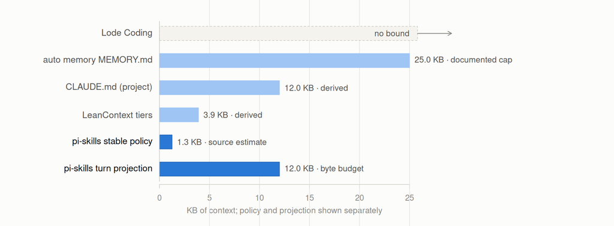

Two further conclusions fall out of the table:

1. On **history and query**, nothing here is close to what the statement log does.
2. On **erasure**, we are the weakest system in the table. Append-only means a leaked token is permanent and `as_of` faithfully replays it forever.

## 6. What integration means, concretely

### 6.1 Option A — Lode as files (rejected)

Add `lode/lode-map.md`, `summary.md`, `terminology.md`, `plans/`, `tmp/`, plus an AGENTS.md section per repo. Rejected for three stated reasons: markdown sprawl; no history beyond per-file git; and text files are not more portable than one SQLite file with a query surface. Nothing below revisits this.

### 6.2 Option B — Lode as vocabulary inside `memory` (recommended)

**Zero new tables.** A lode entry is a set of statements under a distinct stanza namespace, so it never enters `note_statement`, the wake frontier, or the summary tree.

```
graph      project:github.com/RGenomicsETL/duckhts
subject    lode:entry/vendoring
```

| Predicate | Value |
| --- | --- |
| `lode:kind` | `hardstop` · `decision` · `constraint` · `invariant` · `term` · `data` · `gap` |
| `lode:title` | short name |
| `lode:text` | one line, ≤512 bytes |
| `lode:authority` | repo paths that win on conflict |
| `lode:covers` | globs — used for **both** staleness and retrieval |
| `lode:verifiedRev` / `lode:verifiedNote` | git rev + evidence sentence |
| `lode:status` | `active` · `retired` · `gap` |
| `lode:supersedes` / `lode:relatesTo` / `lode:inherits` | object edges, walkable with recursive SQL |

Note the kinds that were **cut**: `area` and `interface`. Both invite exactly the inferable description LeanContext bans. Every surviving kind is non-inferable by construction, and `kind=decision` fails the write without a rejected-alternatives value — the ADR shape enforced rather than templated.

| Concern | Mechanism |
| --- | --- |
| Read the map before searching | `SELECT` over active entries in the project graph — cannot go stale, never hand-maintained |
| Per-claim history | free from `statement_history` |
| “What did we believe in June” | free from `as_of_statement` |
| Retirement | append `lode:status = retired`; the entry stays inspectable |
| Org-wide rules | `lode:inherits` edge to an org graph; no snapshot, no drift |
| Cross-machine | `memory export --graph project:<id>` → one sorted JSONL at the repo root; `memory import` replays it as one transaction |

### 6.3 Option C — LeanContext as classification (adopt alongside B)

Their three tiers are not three files for us; they are three mechanisms we own.

| LeanContext tier | Their form | Our form |
| --- | --- | --- |
| Constitution | `CONSTITUTION.md`, symlinked to `AGENTS.md` | stable system-prompt policy + `sounkou-engineering-style`; per-repo `kind=hardstop` entries |
| Manifest | hand-maintained table | the lode map, built by `SELECT` |
| Supply | `.context/*.md` | skill progressive disclosure, FTS recall, `lode open` |
| Workbench rule | stated | `context-budget`, enforced in bytes |
| Shadow Board rule | stated | Pi’s skill listing |
| Pull rule | manifest discipline | per-turn projection built from the prompt |
| Session discipline | prose | Plannotator local review and native Pi tree exploration |
| Compaction | manual demotion | note stream + summary tree (`nap` / `zoom`) — no equivalent on their side |

Three of their ideas are genuinely new to us:

1. **Knowledge boundary as a write gate.** Refuse entries that restate what the code shows.
2. **Gaps as rows.** Their bootstrap leaves `<!-- FILL IN: why was this chosen? -->` in a file; ours becomes `lode:status = gap` — a question with no answer, surfaced in the projection until answered. The Andon Rule as queryable state.
3. **Demotion, not deletion.** A hardstop failing the irreversibility test gets `lode:kind` re-appended as `constraint`; identity and history survive.

### 6.4 What Claude Code contributes

| Borrowing | Their implementation | Ours |
| --- | --- | --- |
| **Redaction** | `redact` clears content, keeps actor + timestamps | new `redact` op: null the `value` at `(transaction_id, ordinal)`, keep the row, log the erasure as its own transaction with a reason |
| **Glob triggering** | `.claude/rules/` with `paths:` loads on matching file reads | entries whose `lode:covers` match files touched this turn join the projection — the Pull Rule, using a field we already store |
| **Enforced budget** | index over 200 lines / 25 KB → error telling Claude to rewrite it | `entry` write fails when the hardstop cap is exceeded, instead of silently dropping projection rows |
| **Age on every fact** | `modified` frontmatter stamp | render `transaction_time` (or `verified N commits ago`) in the projection — a claim without its date invites over-trust |
| **Placement** | CLAUDE.md is a user message *after* the system prompt, even for managed policy | keep hardstops in the per-turn projection, **not** the cache prefix |

That last row reverses an earlier recommendation of mine, and it comes with a free property: Claude Code must specially re-read and re-inject project CLAUDE.md after `/compact`, and admits nested files and `paths:` rules are *not* re-injected — a projection rebuilt from SQL every user turn simply reappears.

## 7. Implementation delta

[output not shown]

Tests to add in `memory.test.ts`: field supersede + `as_of` at an older transaction; retire hides from the map but keeps history; **note stream and summary tree unaffected by lode statements**; redact nulls content but preserves the transaction; export → import is idempotent; FTS finds an entry.

No `SCHEMA_VERSION` bump: no new tables, and the new views carry new names.

## 8. Open decisions

1. **Multi-valued `lode:covers`.** Slot semantics means one statement per predicate. A space-separated glob list keeps supersede exact and diffs readable; set membership via object nodes would need tombstones. Proposed: delimited value, capped.
2. **Org graph naming.** `org:RGenomicsETL` versus a normalized org URL. Affects `lode:inherits` and the export.
3. **Where the export lives.** `lode.jsonl` at the repo root versus `.pi/lode.jsonl`.
4. **Redaction scope.** Value only, or also subject/predicate when those leak — a path can be the secret.

*Rendered with litedown 0.10. Figures are computed from the sources in this repository; re-render with* `Rscript -e 'litedown::fuse("docs/memory-lode-design.Rmd")'`.